# Modeling and prediction for movies

## Setup

### Load packages

```r
library(ggplot2)
library(dplyr)
library(statsr)
library(GGally)
```

### Load data

```r
load("movies.Rdata")
```

### Define *multiplot* function for later use

The following source code is available at Cookbook for R under the [CCO](https://creativecommons.org/publicdomain/zero/1.0/) license.

```r
multiplot <- function(..., plotlist=NULL, file, cols=1, layout=NULL) {
  library(grid)

  # Make a list from the ... arguments and plotlist
  plots <- c(list(...), plotlist)

  numPlots = length(plots)

  # If layout is NULL, then use 'cols' to determine layout
  if (is.null(layout)) {
    # Make the panel
    # ncol: Number of columns of plots
    # nrow: Number of rows needed, calculated from # of cols
    layout <- matrix(seq(1, cols * ceiling(numPlots/cols)),
                    ncol = cols, nrow = ceiling(numPlots/cols))
  }

 if (numPlots==1) {
    print(plots[[1]])

  } else {
    # Set up the page
    grid.newpage()
    pushViewport(viewport(layout = grid.layout(nrow(layout), ncol(layout))))

    # Make each plot, in the correct location
    for (i in 1:numPlots) {
      # Get the i,j matrix positions of the regions that contain this subplot
      matchidx <- as.data.frame(which(layout == i, arr.ind = TRUE))

      print(plots[[i]], vp = viewport(layout.pos.row = matchidx$row,
                                      layout.pos.col = matchidx$col))
    }
  }
}
```

## Part 1: Data

The database consists of 651 observations of 32 variables. Each observation represents a movie randomly sampled among those who have been released in theatres between 1972 and 2014. The practice of random sampling allows to generalize the results of this study to movies released in the same period of time. It is not completely sure that the results can be generalized to movies released in the several decades before (for instance in the Twenties) due to the shifting tastes of the public and to the technological changes in the movie industry, which have re-defined the cinematographic art in the latest decades.

No random assignment has been applied, therefore it is not possible to establish a link of causality between variables.

## Part 3: Exploratory data analysis

The first step of the exploratory data analysis is to select the subset of variables that may reasonably be correlated to *audience_score*. The names of the actors, of the director, the urls, the title, the genre, the studio that produced the movie and the *mpaa_rating* variable are therefore left out of the evaluation. We are only going to work with numerical variables or two-valued (*Yes*/*No*) categorical variables.

```r
reduced <- movies[,c("runtime","thtr_rel_year","imdb_rating","imdb_num_votes","critics_score",
                     "audience_score","best_pic_nom","best_pic_win","best_actor_win",
                     "best_actress_win", "best_dir_win", "top200_box")]
```

In order to tidy the data for the linear regression, it is also a good practice to delete all rows of the database that contain NaN entries.

```r
reduced <- reduced[complete.cases(reduced), ]
```

The distribution of the *audience_score* with respect to the six categorical variables can be inspected by means of box plots, which are presented below in a compact layout.

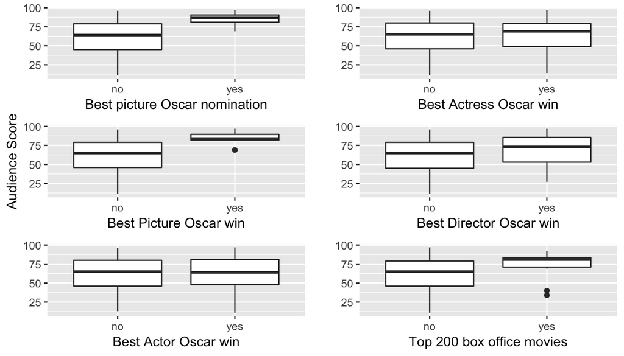

```r
p1 <- ggplot(reduced, aes(best_pic_nom, audience_score)) + geom_boxplot() +
  labs(x = "Best picture Oscar nomination", y = "")

p2 <- ggplot(reduced, aes(best_pic_win, audience_score)) + geom_boxplot() +
  labs(x = "Best Picture Oscar win", y = "Audience Score")

p3 <- ggplot(reduced, aes(best_actor_win, audience_score)) + geom_boxplot() +
  labs(x = "Best Actor Oscar win", y = "")

p4 <- ggplot(reduced, aes(best_actress_win, audience_score)) + geom_boxplot() +
  labs(x = "Best Actress Oscar win", y = "")

p5 <- ggplot(reduced, aes(best_dir_win, audience_score)) + geom_boxplot() +
  labs(x = "Best Director Oscar win", y = "")

p6 <- ggplot(reduced, aes(top200_box, audience_score)) + geom_boxplot() +
  labs(x = "Top 200 box office movies", y = "")

multiplot(p1, p2, p3, p4, p5, p6, cols=2)
```

From this exploratory visualization, it seems that the fact that the director or one of the actors or actresses has previously won an Oscar is not highly correlated with the audience score. On the contrary, the victory of the movie at the Academy Awards, or even a simple nomination, seems to make a greater difference with regards to the public appreciation. Another categorical variable that may affect the prediction of the audience score is apparently whether or not the movie is in the Top 200 Box Office list on BoxOfficeMojo. In any case, the statistical significance of each variable will be evaluated in the modeling section.

The relationship between various numerical variables can be evaluated by means of the following generalized pairs plot.

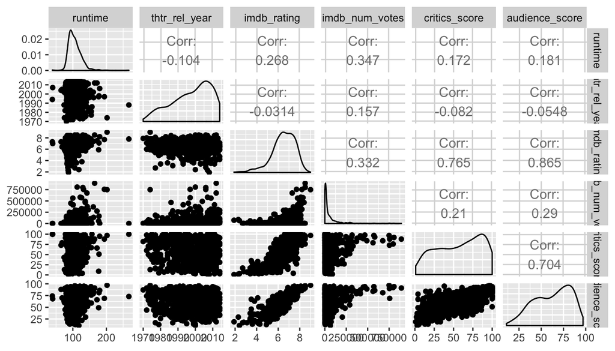

```r
ggpairs(reduced, columns = 1:6)
```

Some interesting trends can be observed in the previous plots. For instance, movie ratings on Imdb are positively and non-linearly correlated with the number of votes a movie gets on Imdb. The variables *imdb_rating* and *audience_score* show a strong positive linear correlation. However, looking at the distribution plots on the diagonal, it appears that the distribution of *imdb_rating* is more strongly left-skewed than that of *audience_score*. Another variable that is expected to play a significant role in the prediction of the audience score is the critics score. In fact, these two variables also show a strong positive linear relation.

This EDA has highlighted that most probably some of the variables included in the *reduced* database are redudant for the purpose of audience score prediction. The next section will highlight a method of selection of the significant variables in order to reach a parsimonious model.

## Part 4: Modeling

The quest for a parsimonious model of the *audience_score* begins with the full model including the following numerical variables:

- *runtime*
- *thtr_rel_year*
- *imdb_rating*
- *imdb_num_votes*
- *critics_score*

and the following categorical variables:

- *best_pic_nom*
- *best_pic_win*
- *best_actor_win*
- *best_actress_win*
- *best_dir_win*
- *top200_box*

The full linear regression model is constructed by means of the following code, which will also output some useful statistics.

```r
m_reg <- lm(audience_score ~  runtime + thtr_rel_year + imdb_rating +
              imdb_num_votes + critics_score + best_pic_nom + best_pic_win +
              best_actor_win + best_actress_win + best_dir_win +
              top200_box, data = reduced)
summary(m_reg)
```

```
##
## Call:
## lm(formula = audience_score ~ runtime + thtr_rel_year + imdb_rating +
##     imdb_num_votes + critics_score + best_pic_nom + best_pic_win +
##     best_actor_win + best_actress_win + best_dir_win + top200_box,
##     data = reduced)
##
## Residuals:
##     Min      1Q  Median      3Q     Max
## -26.662  -6.461   0.291   5.717  52.090
##
## Coefficients:
##                       Estimate Std. Error t value Pr(>|t|)
## (Intercept)          9.602e+01  7.536e+01   1.274   0.2031
## runtime             -5.511e-02  2.347e-02  -2.348   0.0192 *
## thtr_rel_year       -6.396e-02  3.753e-02  -1.704   0.0888 .
## imdb_rating          1.481e+01  5.911e-01  25.061   <2e-16 ***
## imdb_num_votes       4.876e-06  4.341e-06   1.123   0.2618
## critics_score        6.775e-02  2.173e-02   3.118   0.0019 **
## best_pic_nomyes      5.031e+00  2.609e+00   1.928   0.0542 .
## best_pic_winyes     -2.631e+00  4.608e+00  -0.571   0.5682
## best_actor_winyes   -1.688e+00  1.176e+00  -1.435   0.1517
## best_actress_winyes -2.069e+00  1.301e+00  -1.590   0.1122
## best_dir_winyes     -1.528e+00  1.725e+00  -0.886   0.3759
## top200_boxyes        1.263e+00  2.763e+00   0.457   0.6476
## ---
## Signif. codes:  0 '***' 0.001 '**' 0.01 '*' 0.05 '.' 0.1 ' ' 1
##
## Residual standard error: 10 on 638 degrees of freedom
## Multiple R-squared:  0.7598, Adjusted R-squared:  0.7557
## F-statistic: 183.5 on 11 and 638 DF,  p-value: < 2.2e-16
```

Starting from the last line of the output, we see an evaluation of the significance of the model as a whole by means of a F-test. The *p-value: < 2.2e-16* allows to reject a null hypothesis stating that all the slopes $\beta_i$ are equal to zero. The Adjusted R-squared value means that that the model accounts for approximately $75.6\%$ of the variability in the sampled *audience_score*. Associated to each predictor is also a *p-value* which is conditional on all the other variables being included in the model. These values are calculated on a *t* distribution with $n - k -1$ degrees of freedom, where $n$ is the number of observations and $k$ is the number of predictors. We adopt a **backward** selection strategy, whereby at each iteration we drop the predictor with the highest associated *p-value* and we re-train the linear regression model. The selection process will stop when all the predictors have *p-value* $< 0.1$. The backward selection is preferred to the forward method essentially because it is faster in that it requires the evaluation of a smaller number of linear models.

The iterations of the backward selection of the parsimonious linear model are reported below.

```r
m_reg <- lm(audience_score ~  runtime + thtr_rel_year + imdb_rating +
            imdb_num_votes + critics_score + best_pic_nom + best_pic_win +
            best_actor_win + best_actress_win + best_dir_win, data = reduced)
summary(m_reg)
```

```
##
## Call:
## lm(formula = audience_score ~ runtime + thtr_rel_year + imdb_rating +
##     imdb_num_votes + critics_score + best_pic_nom + best_pic_win +
##     best_actor_win + best_actress_win + best_dir_win, data = reduced)
##
## Residuals:
##     Min      1Q  Median      3Q     Max
## -26.642  -6.446   0.283   5.788  52.095
##
## Coefficients:
##                       Estimate Std. Error t value Pr(>|t|)
## (Intercept)          1.001e+02  7.479e+01   1.338  0.18137
## runtime             -5.488e-02  2.345e-02  -2.340  0.01958 *
## thtr_rel_year       -6.597e-02  3.725e-02  -1.771  0.07704 .
## imdb_rating          1.480e+01  5.899e-01  25.089  < 2e-16 ***
## imdb_num_votes       5.426e-06  4.169e-06   1.302  0.19349
## critics_score        6.835e-02  2.168e-02   3.153  0.00169 **
## best_pic_nomyes      4.995e+00  2.606e+00   1.917  0.05570 .
## best_pic_winyes     -2.647e+00  4.605e+00  -0.575  0.56567
## best_actor_winyes   -1.677e+00  1.175e+00  -1.427  0.15407
## best_actress_winyes -2.047e+00  1.299e+00  -1.575  0.11565
## best_dir_winyes     -1.556e+00  1.723e+00  -0.903  0.36671
## ---
## Signif. codes:  0 '***' 0.001 '**' 0.01 '*' 0.05 '.' 0.1 ' ' 1
##
## Residual standard error: 9.996 on 639 degrees of freedom
## Multiple R-squared:  0.7597, Adjusted R-squared:  0.756
## F-statistic: 202.1 on 10 and 639 DF,  p-value: < 2.2e-16
```

```r
m_reg <- lm(audience_score ~  runtime + thtr_rel_year + imdb_rating +
              imdb_num_votes + critics_score + best_pic_nom +
              best_actor_win + best_actress_win + best_dir_win, data = reduced)
summary(m_reg)
```

```
##
## Call:
## lm(formula = audience_score ~ runtime + thtr_rel_year + imdb_rating +
##     imdb_num_votes + critics_score + best_pic_nom + best_actor_win +
##     best_actress_win + best_dir_win, data = reduced)
##
## Residuals:
##     Min      1Q  Median      3Q     Max
## -26.670  -6.458   0.258   5.782  52.091
##
## Coefficients:
##                       Estimate Std. Error t value Pr(>|t|)
## (Intercept)          9.834e+01  7.469e+01   1.317  0.18842
## runtime             -5.478e-02  2.344e-02  -2.337  0.01973 *
## thtr_rel_year       -6.513e-02  3.720e-02  -1.751  0.08048 .
## imdb_rating          1.481e+01  5.892e-01  25.134  < 2e-16 ***
## imdb_num_votes       5.030e-06  4.109e-06   1.224  0.22136
## critics_score        6.824e-02  2.166e-02   3.150  0.00171 **
## best_pic_nomyes      4.402e+00  2.391e+00   1.841  0.06613 .
## best_actor_winyes   -1.626e+00  1.171e+00  -1.388  0.16557
## best_actress_winyes -2.085e+00  1.297e+00  -1.608  0.10838
## best_dir_winyes     -1.826e+00  1.656e+00  -1.102  0.27075
## ---
## Signif. codes:  0 '***' 0.001 '**' 0.01 '*' 0.05 '.' 0.1 ' ' 1
##
## Residual standard error: 9.991 on 640 degrees of freedom
## Multiple R-squared:  0.7596, Adjusted R-squared:  0.7562
## F-statistic: 224.7 on 9 and 640 DF,  p-value: < 2.2e-16
```

```r
m_reg <- lm(audience_score ~  runtime + thtr_rel_year + imdb_rating +
              imdb_num_votes + critics_score + best_pic_nom +
              best_actor_win + best_actress_win, data = reduced)
summary(m_reg)
```

```
##
## Call:
## lm(formula = audience_score ~ runtime + thtr_rel_year + imdb_rating +
##     imdb_num_votes + critics_score + best_pic_nom + best_actor_win +
##     best_actress_win, data = reduced)
##
## Residuals:
##     Min      1Q  Median      3Q     Max
## -26.671  -6.471   0.308   5.500  52.055
##
## Coefficients:
##                       Estimate Std. Error t value Pr(>|t|)
## (Intercept)          9.057e+01  7.437e+01   1.218  0.22374
## runtime             -5.866e-02  2.318e-02  -2.531  0.01161 *
## thtr_rel_year       -6.108e-02  3.703e-02  -1.650  0.09953 .
## imdb_rating          1.482e+01  5.892e-01  25.158  < 2e-16 ***
## imdb_num_votes       4.544e-06  4.086e-06   1.112  0.26658
## critics_score        6.688e-02  2.163e-02   3.092  0.00208 **
## best_pic_nomyes      4.278e+00  2.389e+00   1.791  0.07382 .
## best_actor_winyes   -1.667e+00  1.171e+00  -1.424  0.15494
## best_actress_winyes -2.104e+00  1.297e+00  -1.622  0.10525
## ---
## Signif. codes:  0 '***' 0.001 '**' 0.01 '*' 0.05 '.' 0.1 ' ' 1
##
## Residual standard error: 9.992 on 641 degrees of freedom
## Multiple R-squared:  0.7592, Adjusted R-squared:  0.7561
## F-statistic: 252.6 on 8 and 641 DF,  p-value: < 2.2e-16
```

```r
m_reg <- lm(audience_score ~  runtime + thtr_rel_year + imdb_rating +
              critics_score + best_pic_nom +
              best_actor_win + best_actress_win, data = reduced)
summary(m_reg)
```

```
##
## Call:
## lm(formula = audience_score ~ runtime + thtr_rel_year + imdb_rating +
##     critics_score + best_pic_nom + best_actor_win + best_actress_win,
##     data = reduced)
##
## Residuals:
##     Min      1Q  Median      3Q     Max
## -26.850  -6.408   0.321   5.474  52.194
##
## Coefficients:
##                     Estimate Std. Error t value Pr(>|t|)
## (Intercept)         71.25370   72.32402   0.985  0.32490
## runtime             -0.05216    0.02243  -2.325  0.02036 *
## thtr_rel_year       -0.05202    0.03613  -1.440  0.15035
## imdb_rating         14.95544    0.57718  25.911  < 2e-16 ***
## critics_score        0.06551    0.02160   3.033  0.00252 **
## best_pic_nomyes      4.91090    2.32070   2.116  0.03472 *
## best_actor_winyes   -1.70484    1.17058  -1.456  0.14577
## best_actress_winyes -2.07400    1.29705  -1.599  0.11031
## ---
## Signif. codes:  0 '***' 0.001 '**' 0.01 '*' 0.05 '.' 0.1 ' ' 1
##
## Residual standard error: 9.994 on 642 degrees of freedom
## Multiple R-squared:  0.7587, Adjusted R-squared:  0.7561
## F-statistic: 288.3 on 7 and 642 DF,  p-value: < 2.2e-16
```

```r
m_reg <- lm(audience_score ~  runtime + imdb_rating +
              critics_score + best_pic_nom +
              best_actor_win + best_actress_win, data = reduced)
summary(m_reg)
```

```
##
## Call:
## lm(formula = audience_score ~ runtime + imdb_rating + critics_score +
##     best_pic_nom + best_actor_win + best_actress_win, data = reduced)
##
## Residuals:
##     Min      1Q  Median      3Q     Max
## -27.333  -6.587   0.122   5.616  51.861
##
## Coefficients:
##                      Estimate Std. Error t value Pr(>|t|)
## (Intercept)         -32.78451    3.30901  -9.908  < 2e-16 ***
## runtime              -0.04933    0.02236  -2.206  0.02773 *
## imdb_rating          14.89679    0.57622  25.852  < 2e-16 ***
## critics_score         0.06846    0.02152   3.181  0.00154 **
## best_pic_nomyes       4.94041    2.32255   2.127  0.03379 *
## best_actor_winyes    -1.65405    1.17102  -1.412  0.15829
## best_actress_winyes  -2.05643    1.29807  -1.584  0.11364
## ---
## Signif. codes:  0 '***' 0.001 '**' 0.01 '*' 0.05 '.' 0.1 ' ' 1
##
## Residual standard error: 10 on 643 degrees of freedom
## Multiple R-squared:  0.7579, Adjusted R-squared:  0.7556
## F-statistic: 335.5 on 6 and 643 DF,  p-value: < 2.2e-16
```

```r
m_reg <- lm(audience_score ~  runtime + imdb_rating +
              critics_score + best_pic_nom +
              best_actress_win, data = reduced)
summary(m_reg)
```

```
##
## Call:
## lm(formula = audience_score ~ runtime + imdb_rating + critics_score +
##     best_pic_nom + best_actress_win, data = reduced)
##
## Residuals:
##     Min      1Q  Median      3Q     Max
## -27.175  -6.617   0.331   5.534  52.008
##
## Coefficients:
##                      Estimate Std. Error t value Pr(>|t|)
## (Intercept)         -32.35127    3.29731  -9.811  < 2e-16 ***
## runtime              -0.05618    0.02185  -2.571  0.01035 *
## imdb_rating          14.90924    0.57660  25.857  < 2e-16 ***
## critics_score         0.06843    0.02154   3.177  0.00156 **
## best_pic_nomyes       4.63401    2.31418   2.002  0.04566 *
## best_actress_winyes  -2.18488    1.29589  -1.686  0.09228 .
## ---
## Signif. codes:  0 '***' 0.001 '**' 0.01 '*' 0.05 '.' 0.1 ' ' 1
##
## Residual standard error: 10.01 on 644 degrees of freedom
## Multiple R-squared:  0.7572, Adjusted R-squared:  0.7553
## F-statistic: 401.6 on 5 and 644 DF,  p-value: < 2.2e-16
```

The final linear model is made up with the following predictors:

- *runtime*
- *imdb_rating*
- *critics_score*
- *best_pic_nom*
- *best_actress_win*

The parsimonious model still accounts for $75\%$ of the variation of the response variable, suggesting that all redundant variables have been eliminated from the full model. The function *confint* allows to calculate a confidence interval for the slope of each predictor, $\beta_i$. Consistently with the significance level imposed on the *p-value*, we calculate $90\%$ confidence intervals for the predictors.

```r
confint(m_reg, level = 0.90)
```

```
##                              5 %         95 %
## (Intercept)         -37.78266662 -26.91986673
## runtime              -0.09216808  -0.02019020
## imdb_rating          13.95945075  15.85902872
## critics_score         0.03295180   0.10390613
## best_pic_nomyes       0.82204280   8.44598601
## best_actress_winyes  -4.31949720  -0.05027256
```

It can be noticed that none of these intervals contains the value $0$. Therefore, all the predictors are statistically significant at the $90\%$ confidence level. Interestingly, the model predicts that the fact that the leading actress has previously won an Oscar might decrease, on average, the audience score of the movie.

The final and most important step in the construction of the model consists of checking the conditions for linear regression.

1. **Independence of observations** is ensured by random sampling.
2. **Linear relationship between each (numerical) explanatory variable and the response**. The generalized pairs plot depicted in the previous section shows a clear linear relationship of *audience_score* with *imdb_rating* and *critics_score*. In the case of *runtime*, the linear relationship is less evident.
3. **Nearly normal residuals**. This condition can be checked observing the following quantile-quantile plot, where the line represents the theoretical normal distribution and the points represent the actual distribution of the residuals.

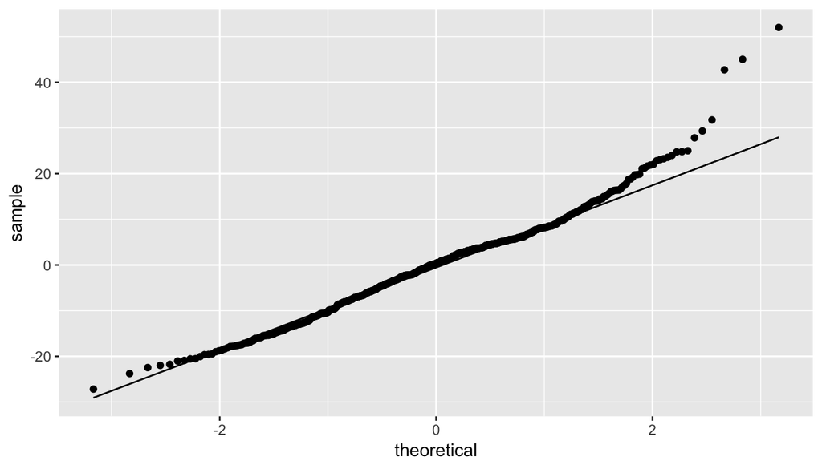

```r
ggplot(data = m_reg, aes(sample = .resid)) +
  stat_qq() + stat_qq_line()
```

Except for a few outliers at the extremes of the distribution, near-normality of the residuals may reasonably be assumed.

4. **Constant variability of residuals**. This condition can be checked by plotting the residuals against the fitted response variable, as in the graph below.

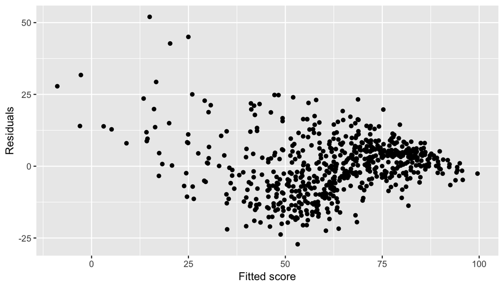

```r
ggplot(data = m_reg, aes(x = .fitted, y = .resid)) + geom_point() +
xlab("Fitted score") + ylab("Residuals")
```

## Part 5: Prediction

The model is used to predict the audience score of the 2016 movie *Jane Got a Gun*. Aggregating data from [Rotten Tomatoes](https://www.rottentomatoes.com/m/jane_got_a_gun/), [Imdb](https://www.imdb.com/title/tt2140037/?ref_=nm_flmg_dr_9) and [Wikipedia](https://en.wikipedia.org/wiki/Jane_Got_a_Gun) it is possible to find all the necessary input for the model. The input is arranged in a new data frame with the following code.

```r
newmovie <- data.frame(runtime = 98, imdb_rating = 5.9, critics_score = 43,
                       best_pic_nom = "no", best_actress_win = "yes")
```

The prediction is realised with the following code. We are interested in getting a prediction interval at the $90\%$ confidence level.

```r
predict(m_reg, newmovie, interval = "prediction", level = 0.90)
```

```
##        fit      lwr      upr
## 1 50.86525 34.24242 67.48808
```

Hence, the model predicts, with $90\%$ confidence, that the Audience Score on Rotten Tomatoes for the movie *Jane Got a Gun* is approximately between $34.24$ and $67.49$. This interval is centred on the predicted score $50.86$. The true Audience Score on Rotten Tomatoes is $37$, a value which is contained in the prediction interval (and is closer to its lower bound).

## Part 6: Conclusion

This brief report has outlined the steps of the generation of a multiple linear regression model for the prediction of a numerical response variable on the basis of various numerical and categorical explanatory variables. The model has been built with a backward approach based on the statistical significance of each predictor, conditional to all other predictors being included in the model. It has been shown that the requirement of constant variability of the residuals is not satisfied. Nevertheless, the model yielded a result resonably close to the real value for a test case not present in the training database.